# TheraBankPersonalLoanCampaign

### Thera Bank Personal Loan Campaign

*Domain:* Banking

*Context:*

This case is about a bank (Thera Bank) whose management wants to explore ways of converting its liability

customers to personal loan customers (while retaining them as depositors). A campaign that the bank ran

last year for liability customers showed a healthy conversion rate of over 9% success. This has encouraged

the retail marketing department to devise campaigns with better target marketing to increase the success

ratio with a minimal budget.

### Objective:

The classification goal is to predict the likelihood of a liability customer buying personal loans.

### `Dataset Information:`

The dataset contains data on 5000 customers. The data include customer demographic information (age, income, etc.), the customer's relationship with the bank (mortgage, securities account, etc.), and the customer response to the last personal loan campaign (Personal Loan). Among these 5000 customers, only 480 (= 9.6%) accepted the personal loan that was offered to them in the earlier campaign.

### `Attribute Information:`

*ID:* Customer ID *Age:* Customer's age in completed years  
*Experience:* years of professional experience  
*Income:* Annual income of the customer  
*ZIP Code:* Home Address ZIP  
*Family:* Family size of the customer  
*CCAvg:* Avg. spending on credit cards per month  
*Education:* Education Level. 1: Undergrad; 2: Graduate; 3: Advanced/Professional  
*Mortgage:* Value of house mortgage if any. ($000)  
*Personal Loan:* Did this customer accept the personal loan offered in the last campaign?  
*Securities Account:* Does the customer have a securities account with the bank?  
*CD Account:* Does the customer have a certificate of deposit (CD) account with the bank?  
*Online:* Does the customer use internet banking facilities?  
*Credit card:* Does the customer use a credit card issued by the bank?

### 1. Import the datasets and libraries, check datatype, statistical summary, shape, null values or incorrect imputation. (5 marks)

```python
import pandas as pd
import numpy as np
import seaborn as sns

from sklearn.linear_model import LogisticRegression

from sklearn.metrics import confusion_matrix, recall_score, precision_score, \
f1_score, roc_auc_score,accuracy_score, roc_curve

# importing ploting libraries
import matplotlib.pyplot as plt

# To enable plotting graphs in Jupyter notebook
%matplotlib inline

#Sklearn package's data splitting function which is based on random function
from sklearn.model_selection import train_test_split

from scipy import stats
```

```python
loan = pd.read_csv("Bank_Personal_Loan_Modelling.csv")
loan
```

|  | ID | Age | Experience | Income | ZIP Code | Family | CCAvg | Education | Mortgage | Personal Loan | Securities Account | CD Account | Online | CreditCard |
| --- | --- | --- | --- | --- | --- | --- | --- | --- | --- | --- | --- | --- | --- | --- |
| 0 | 1 | 25 | 1 | 49 | 91107 | 4 | 1.6 | 1 | 0 | 0 | 1 | 0 | 0 | 0 |
| 1 | 2 | 45 | 19 | 34 | 90089 | 3 | 1.5 | 1 | 0 | 0 | 1 | 0 | 0 | 0 |
| 2 | 3 | 39 | 15 | 11 | 94720 | 1 | 1.0 | 1 | 0 | 0 | 0 | 0 | 0 | 0 |
| 3 | 4 | 35 | 9 | 100 | 94112 | 1 | 2.7 | 2 | 0 | 0 | 0 | 0 | 0 | 0 |
| 4 | 5 | 35 | 8 | 45 | 91330 | 4 | 1.0 | 2 | 0 | 0 | 0 | 0 | 0 | 1 |
| ... | ... | ... | ... | ... | ... | ... | ... | ... | ... | ... | ... | ... | ... | ... |
| 4995 | 4996 | 29 | 3 | 40 | 92697 | 1 | 1.9 | 3 | 0 | 0 | 0 | 0 | 1 | 0 |
| 4996 | 4997 | 30 | 4 | 15 | 92037 | 4 | 0.4 | 1 | 85 | 0 | 0 | 0 | 1 | 0 |
| 4997 | 4998 | 63 | 39 | 24 | 93023 | 2 | 0.3 | 3 | 0 | 0 | 0 | 0 | 0 | 0 |
| 4998 | 4999 | 65 | 40 | 49 | 90034 | 3 | 0.5 | 2 | 0 | 0 | 0 | 0 | 1 | 0 |
| 4999 | 5000 | 28 | 4 | 83 | 92612 | 3 | 0.8 | 1 | 0 | 0 | 0 | 0 | 1 | 1 |

5000 rows × 14 columns

```python
loan.info()
```

```
<class 'pandas.core.frame.DataFrame'>
RangeIndex: 5000 entries, 0 to 4999
Data columns (total 14 columns):
ID                    5000 non-null int64
Age                   5000 non-null int64
Experience            5000 non-null int64
Income                5000 non-null int64
ZIP Code              5000 non-null int64
Family                5000 non-null int64
CCAvg                 5000 non-null float64
Education             5000 non-null int64
Mortgage              5000 non-null int64
Personal Loan         5000 non-null int64
Securities Account    5000 non-null int64
CD Account            5000 non-null int64
Online                5000 non-null int64
CreditCard            5000 non-null int64
dtypes: float64(1), int64(13)
memory usage: 547.0 KB
```

```python
loan.describe()
```

|  | ID | Age | Experience | Income | ZIP Code | Family | CCAvg | Education | Mortgage | Personal Loan | Securities Account | CD Account | Online | CreditCard |
| --- | --- | --- | --- | --- | --- | --- | --- | --- | --- | --- | --- | --- | --- | --- |
| count | 5000.000000 | 5000.000000 | 5000.000000 | 5000.000000 | 5000.000000 | 5000.000000 | 5000.000000 | 5000.000000 | 5000.000000 | 5000.000000 | 5000.000000 | 5000.00000 | 5000.000000 | 5000.000000 |
| mean | 2500.500000 | 45.338400 | 20.104600 | 73.774200 | 93152.503000 | 2.396400 | 1.937938 | 1.881000 | 56.498800 | 0.096000 | 0.104400 | 0.06040 | 0.596800 | 0.294000 |
| std | 1443.520003 | 11.463166 | 11.467954 | 46.033729 | 2121.852197 | 1.147663 | 1.747659 | 0.839869 | 101.713802 | 0.294621 | 0.305809 | 0.23825 | 0.490589 | 0.455637 |
| min | 1.000000 | 23.000000 | -3.000000 | 8.000000 | 9307.000000 | 1.000000 | 0.000000 | 1.000000 | 0.000000 | 0.000000 | 0.000000 | 0.00000 | 0.000000 | 0.000000 |
| 25% | 1250.750000 | 35.000000 | 10.000000 | 39.000000 | 91911.000000 | 1.000000 | 0.700000 | 1.000000 | 0.000000 | 0.000000 | 0.000000 | 0.00000 | 0.000000 | 0.000000 |
| 50% | 2500.500000 | 45.000000 | 20.000000 | 64.000000 | 93437.000000 | 2.000000 | 1.500000 | 2.000000 | 0.000000 | 0.000000 | 0.000000 | 0.00000 | 1.000000 | 0.000000 |
| 75% | 3750.250000 | 55.000000 | 30.000000 | 98.000000 | 94608.000000 | 3.000000 | 2.500000 | 3.000000 | 101.000000 | 0.000000 | 0.000000 | 0.00000 | 1.000000 | 1.000000 |
| max | 5000.000000 | 67.000000 | 43.000000 | 224.000000 | 96651.000000 | 4.000000 | 10.000000 | 3.000000 | 635.000000 | 1.000000 | 1.000000 | 1.00000 | 1.000000 | 1.000000 |

```python
loan.isnull().sum()
```

```
ID                    0
Age                   0
Experience            0
Income                0
ZIP Code              0
Family                0
CCAvg                 0
Education             0
Mortgage              0
Personal Loan         0
Securities Account    0
CD Account            0
Online                0
CreditCard            0
dtype: int64
```

```python
loan.shape
```

```
(5000, 14)
```

### 2. EDA: Study the data distribution in each attribute and target variable, share your findings (20 marks)

a) Number of unique in each column? b) Number of people with zero mortgage?  
c) Number of people with zero credit card spending per month?  
d) Value counts of all categorical columns.  
e) Univariate and Bivariate  
f) Get data model ready

```python
# Number of unique in each columm
loan.nunique()
```

```
ID                    5000
Age                     45
Experience              47
Income                 162
ZIP Code               467
Family                   4
CCAvg                  108
Education                3
Mortgage               347
Personal Loan            2
Securities Account       2
CD Account               2
Online                   2
CreditCard               2
dtype: int64
```

```python
# Number of people with zero mortgage

loan["ID"].where(loan["Mortgage"]==0).count()
```

```
3462
```

```python
# Number of people with zero credit card spending per month
loan["ID"].where(loan["CCAvg"]==0).count()
```

```
106
```

```python
# Value counts of all categorical columns

for i in  ['Family', 'Education', 'Personal Loan', 'Securities Account','CD Account', 'Online',
'CreditCard']:
    print(i, loan[i].nunique())
```

```
Family 4
Education 3
Personal Loan 2
Securities Account 2
CD Account 2
Online 2
CreditCard 2
```

```python
# Univariate and Bivariate
loan.nunique()
```

```
ID                    5000
Age                     45
Experience              47
Income                 162
ZIP Code               467
Family                   4
CCAvg                  108
Education                3
Mortgage               347
Personal Loan            2
Securities Account       2
CD Account               2
Online                   2
CreditCard               2
dtype: int64
```

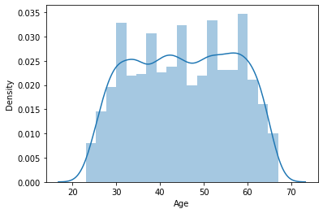

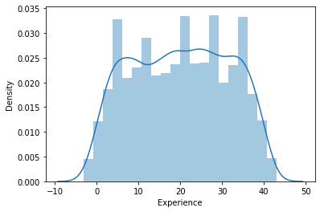

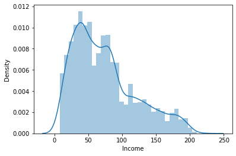

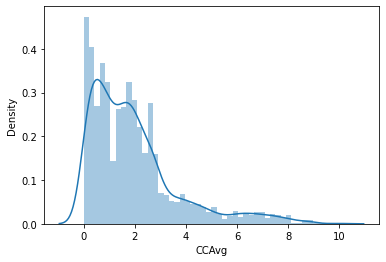

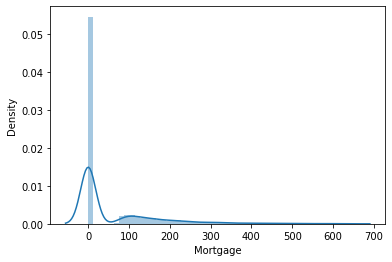

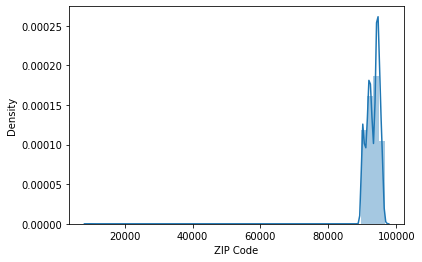

```python
# Univariate and Bivariate


for i in ['Age','Experience','Income','CCAvg','Mortgage', 'ZIP Code']:
    sns.distplot(loan[i])
    plt.show()
```

```python
loan['Age'].value_counts(normalize=True)
```

```
35    0.0302
43    0.0298
52    0.0290
58    0.0286
54    0.0286
50    0.0276
41    0.0272
30    0.0272
56    0.0270
34    0.0268
39    0.0266
59    0.0264
57    0.0264
51    0.0258
60    0.0254
```

[output cut: 31 more lines]

```python
loan['Experience'].value_counts(normalize=True)
```

```
 32    0.0308
 20    0.0296
 9     0.0294
 5     0.0292
 23    0.0288
 35    0.0286
 25    0.0284
 28    0.0276
 18    0.0274
 19    0.0270
 26    0.0268
 24    0.0262
 3     0.0258
 14    0.0254
 16    0.0254
```

[output cut: 33 more lines]

```python
loan['Income'].value_counts(normalize=True)
```

```
44     0.0170
38     0.0168
81     0.0166
41     0.0164
39     0.0162
        ...
189    0.0004
202    0.0004
205    0.0004
224    0.0002
218    0.0002
Name: Income, Length: 162, dtype: float64
```

```python
loan['CCAvg'].value_counts(normalize=True)
```

```
0.30    0.0482
1.00    0.0462
0.20    0.0408
2.00    0.0376
0.80    0.0374
         ...
2.75    0.0002
8.20    0.0002
9.30    0.0002
3.67    0.0002
5.33    0.0002
Name: CCAvg, Length: 108, dtype: float64
```

```python
loan['Mortgage'].value_counts(normalize=True)

# 70% of observations have 0 as Mortgage. Therefore it has no relevancy to the target variable.
```

```
0      0.6924
98     0.0034
103    0.0032
119    0.0032
83     0.0032
        ...
541    0.0002
509    0.0002
505    0.0002
485    0.0002
577    0.0002
Name: Mortgage, Length: 347, dtype: float64
```

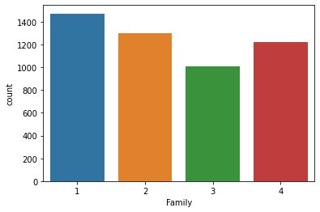

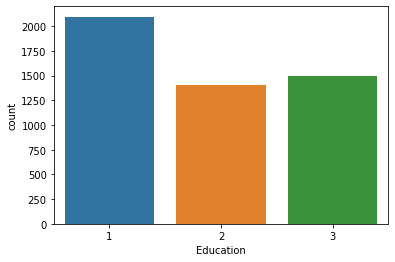

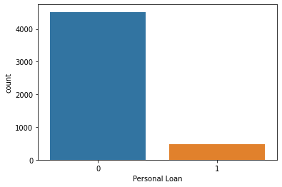

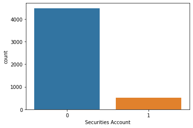

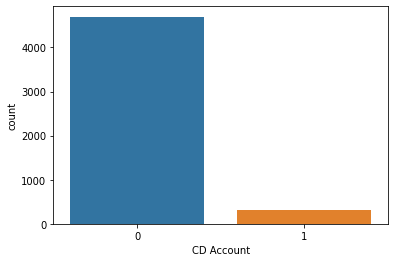

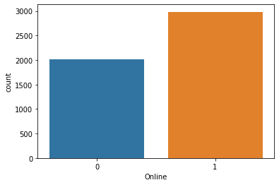

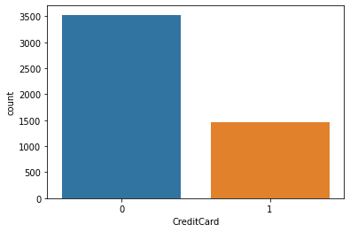

```python
# Univariate and Bivariate

for i in ['Family', 'Education', 'Personal Loan', 'Securities Account','CD Account', 'Online',
'CreditCard']:
    sns.countplot(loan[i])
    plt.show()
```

```python
# Univariate and Bivariate

for i in ['Family', 'Education', 'Personal Loan', 'Securities Account','CD Account', 'Online',
'CreditCard']:
    print(i, loan[i].value_counts(normalize=True))
```

```
Family 1    0.2944
2    0.2592
4    0.2444
3    0.2020
Name: Family, dtype: float64
Education 1    0.4192
3    0.3002
2    0.2806
Name: Education, dtype: float64
Personal Loan 0    0.904
1    0.096
Name: Personal Loan, dtype: float64
Securities Account 0    0.8956
1    0.1044
Name: Securities Account, dtype: float64
CD Account 0    0.9396
1    0.0604
Name: CD Account, dtype: float64
Online 1    0.5968
0    0.4032
Name: Online, dtype: float64
CreditCard 0    0.706
1    0.294
Name: CreditCard, dtype: float64
```

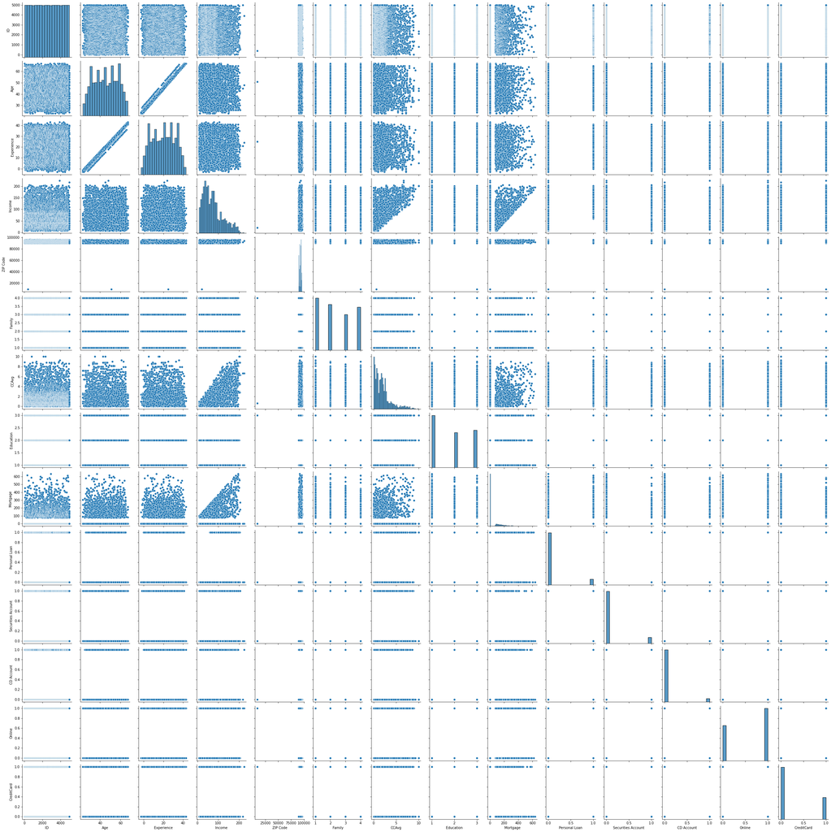

```python
# Univariate and Bivariate
sns.pairplot(loan)
```

```python
pd.crosstab(loan['Family'],loan['Personal Loan'],normalize='index')
```

| Personal Loan Family | 0 | 1 |
| --- | --- | --- |
| 1 | 0.927310 | 0.072690 |
| 2 | 0.918210 | 0.081790 |
| 3 | 0.868317 | 0.131683 |
| 4 | 0.890344 | 0.109656 |

```python
pd.crosstab(loan['Education'],loan['Personal Loan'],normalize='index')
```

[output not shown]

```python
pd.crosstab(loan['Education'],loan['Personal Loan'],normalize='index')
```

| Personal Loan Education | 0 | 1 |
| --- | --- | --- |
| 1 | 0.955630 | 0.044370 |
| 2 | 0.870278 | 0.129722 |
| 3 | 0.863424 | 0.136576 |

```python
pd.crosstab(loan['Securities Account'],loan['Personal Loan'],normalize='index')
```

| Personal Loan Securities Account | 0 | 1 |
| --- | --- | --- |
| 0 | 0.906208 | 0.093792 |
| 1 | 0.885057 | 0.114943 |

```python
pd.crosstab(loan['CD Account'],loan['Personal Loan'],normalize='index')
```

| Personal Loan CD Account | 0 | 1 |
| --- | --- | --- |
| 0 | 0.927629 | 0.072371 |
| 1 | 0.536424 | 0.463576 |

```python
pd.crosstab(loan['Online'],loan['Personal Loan'],normalize='index')
```

| Personal Loan Online | 0 | 1 |
| --- | --- | --- |
| 0 | 0.90625 | 0.09375 |
| 1 | 0.90248 | 0.09752 |

```python
pd.crosstab(loan['CreditCard'],loan['Personal Loan'],normalize='index')
```

| Personal Loan CreditCard | 0 | 1 |
| --- | --- | --- |
| 0 | 0.904533 | 0.095467 |
| 1 | 0.902721 | 0.097279 |

```python
loan.isnull().sum()
```

```
ID                    0
Age                   0
Experience            0
Income                0
ZIP Code              0
Family                0
CCAvg                 0
Education             0
Mortgage              0
Personal Loan         0
Securities Account    0
CD Account            0
Online                0
CreditCard            0
dtype: int64
```

```python
# Get data model ready
# Removing ID  column as its value is unique

loan.drop('ID', axis =1,inplace=True)
```

```python
# Get data model ready
# Removing ZIP Code column

loan.drop('ZIP Code', axis =1,inplace=True)
```

```python
# Get data model ready
# Removing ZIP Code column

loan.drop('Mortgage', axis =1,inplace=True)
```

```python
loan
```

|  | Age | Experience | Income | Family | CCAvg | Education | Personal Loan | Securities Account | CD Account | Online | CreditCard |
| --- | --- | --- | --- | --- | --- | --- | --- | --- | --- | --- | --- |
| 0 | 25 | 1 | 49 | 4 | 1.6 | 1 | 0 | 1 | 0 | 0 | 0 |
| 1 | 45 | 19 | 34 | 3 | 1.5 | 1 | 0 | 1 | 0 | 0 | 0 |
| 2 | 39 | 15 | 11 | 1 | 1.0 | 1 | 0 | 0 | 0 | 0 | 0 |
| 3 | 35 | 9 | 100 | 1 | 2.7 | 2 | 0 | 0 | 0 | 0 | 0 |
| 4 | 35 | 8 | 45 | 4 | 1.0 | 2 | 0 | 0 | 0 | 0 | 1 |
| ... | ... | ... | ... | ... | ... | ... | ... | ... | ... | ... | ... |
| 4995 | 29 | 3 | 40 | 1 | 1.9 | 3 | 0 | 0 | 0 | 1 | 0 |
| 4996 | 30 | 4 | 15 | 4 | 0.4 | 1 | 0 | 0 | 0 | 1 | 0 |
| 4997 | 63 | 39 | 24 | 2 | 0.3 | 3 | 0 | 0 | 0 | 0 | 0 |
| 4998 | 65 | 40 | 49 | 3 | 0.5 | 2 | 0 | 0 | 0 | 1 | 0 |
| 4999 | 28 | 4 | 83 | 3 | 0.8 | 1 | 0 | 0 | 0 | 1 | 1 |

5000 rows × 11 columns

```python
loan.shape
```

```
(5000, 11)
```